# Conclusions

## Conclusions

The comprehensive study of Reddit discussions about Taylor Swift has unveiled multifaceted insights into her global influence, fan engagement, and the nature of her appeal. Our analysis displayed at Figure 1, based on the Reddit data from January 2021 to April 2023, revealed a significant correlation between Taylor Swift’s career milestones and Reddit mentions. Key events like album releases, the Ticketmaster controversy, and the Era’s Tour were notable triggers for spikes in discussions, reflecting her profound impact beyond music.

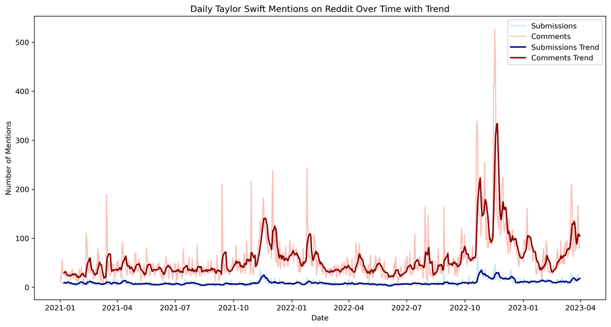

Figure 1: Daily Time Series Plot About Taylor Swift Mentions Over Time

From Figure 2 we can see that Taylor Swift’s influence predominantly resonates in North America, Oceania, and Europe, with a notable presence of non-English speakers, particularly from Europe. The fan engagement analysis further highlighted the active participation of her fans, with certain authors and posts garnering significant attention and upvotes. Through this research, it will be helpful for determining the market expansion overseas.

[interactive chart not shown]

Figure 2: Top 20 Countries Mentioned under Taylor Swift Subreddit

Our exploration of language and word usage in Taylor Swift discussions employed advanced NLP techniques and provided deep insights into the common themes and sentiments prevalent among her fans. This was particularly evident in the word clouds generated at Figure 3 and Figure 4, which emphasized a strong connection of fans with her albums and live performances.

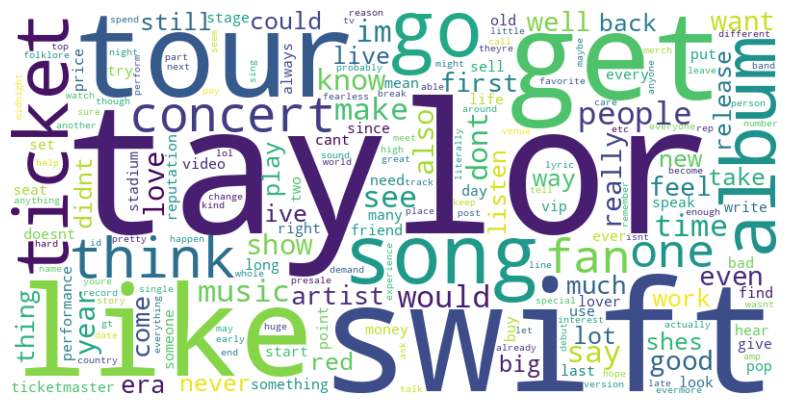

Figure 3: Wordcould Associated with Taylor Swift and Concert

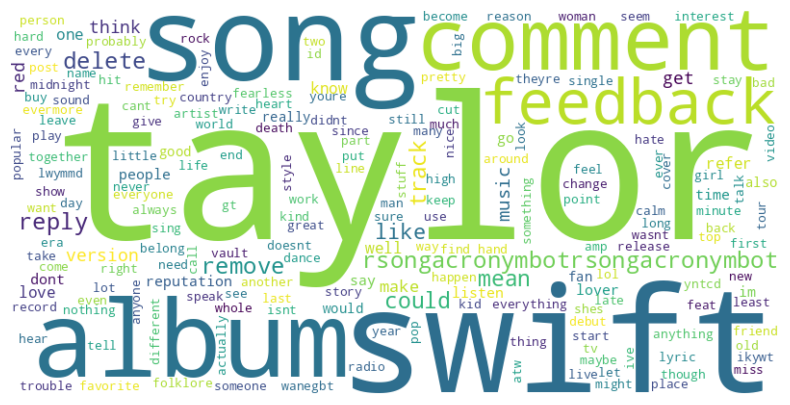

Figure 4: Wordcould Associated with Taylor Swift and Music

The sentiment analysis of Reddit posts revealed a predominantly positive atmosphere within music subreddits, with a higher frequency of positive comments for albums with a higher valence, like “Lover” and “Red” Figure 5. Interestingly, despite the positive sentiment on Reddit, albums like “Reputation” and “Evermore” showed higher popularity on Spotify, indicating a divergence in fan base preferences across platforms.

[interactive chart not shown]

Figure 5: Comments Sentiment and Album Popularity/Energy/Valence

Lastly, our machine learning models successfully predicted the viral potential of Taylor Swift-related posts on Reddit. Although the outcome of the score prediction is not that ideal, we can still make the conslusion that content of the text, originality, and the timing of posts, expecially months, played somehow roles in determining their popularity.

## Next Steps

Moving forward, our project aims to dive deeper into cross-platform analysis to understand how discussions about Taylor Swift vary across different social media platforms. This will help us compare the sentiment, themes, and engagement levels on platforms like Twitter, Instagram, and Tik Tok with Reddit.

We also plan to refine our machine learning models to predict post popularity, focusing on incorporating more nuanced variables such as the specific topics discussed in the text. This will aid in better understanding the content that resonates most with different segments of Taylor Swift’s fan base.

Another area of exploration will be to track the evolution of Taylor Swift’s fan community over time, analyzing how her fan base grows and shifts across various cultural contexts. This could provide valuable insights into the global reach and cultural impact of her music and public persona.

In conclusion, our project has laid a solid foundation for understanding the dynamics of Taylor Swift’s presence and influence on Reddit. The future steps will aim to broaden this understanding across different dimensions and platforms, continuing to provide valuable insights into the intersection of music, fandom, and social media.